# 3.5_DSSD_front_back_correlation_2_new

## 3.5 DSSD front-back Correlation(II)

### 目的：

- 对x-y的所有条进行能量刻度 (幅度归一化)
- 学习进行复杂分析的思路和方法

### 3.4节回顾

- 粒子在入射位置为：xstrip=i条、ystrip=j条，标记为$(i,j)$
- 对于入射到 $(i,j)$ ，能量沉积为E的粒子: $A_i=k_{ij}A_j+b_{ij} $

### 幅度归一化的目标是，将所有条相对于某一参考条$i$条进行刻度。

### 方法1

- 固定参考条$i$条不变，按照上述方程依次遍历所有的$j$条, 得到y面的归一化系数：
  - $A_i=k_{ij}A_j+b_{ij} \to $ $\lbrace k_{i,j},b_{i,j}\rbrace \quad ,j=0,1,...N_j $
- 对y面所有条进行刻度：$\lbrace A'_j=k_{i,j}A_j+b_{i,j} \rbrace\quad ,j=0,1,...N_j$。
- 以刻度后y面某一条$j$条作为参考条，对所有x面的条进行刻度 $ A'_{j}=k_{j,i}A_i+b_{j,i}$

经上述步骤，DSSD的$x$面和$y$面的所有条能量都归一化到第$i$参考条

- 该方法利用的是每个x条和每个y条重叠区域事件(pixel),前提是入射到每一个$(i,j)$ pixel的粒子有足够的统计。

备注：

生成graph程序：fb-fittingall.ipynb

dssd/dssd.C, dssd.h,cut1.C,cut2.C,cut3.C

结果：刻度系数:d1cal.txt,d2cal.txt,d3cal.txt

```python
//%jsroot on
TFile *ipf = new TFile("data_16C.root");
TTree *tree = (TTree*)ipf->Get("tree");
TCanvas *c1=new TCanvas("c1","c1");
```

## 确定每个探测器正背面关联的大致范围

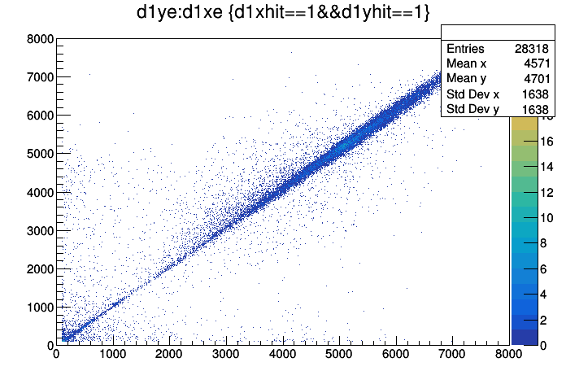

```python
tree->Draw("d1ye:d1xe>>(1000,0,8000,1000,0,8000)","d1xhit==1&&d1yhit==1","colz");
c1->Draw();
int xm,ym;//x/y strip number with maximum counts
```

- 在二维图中选择合适的区域，做TCutG，命名为cutd1xy,保存到cut1.C

[figure not shown]

```python
gROOT->Macro("cut1.C");
```

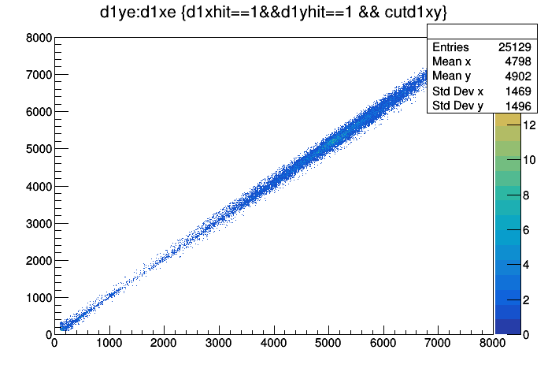

```python
tree->Draw("d1ye:d1xe>>(1000,0,8000,1000,0,8000)","d1xhit==1&&d1yhit==1 && cutd1xy","colz");
c1->Draw();
```

## 找到每个探测器x和y面计数最高条的编号

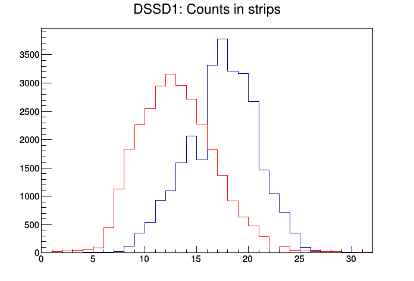

```
xm = 18,ym = 13
```

```python
THStack *hs1 = new THStack("hs1","DSSD1: Counts in strips");
tree->Draw("d1xs>>h1xs(32,0,32)","d1xhit==1 && d1yhit==1");
tree->Draw("d1ys>>h1ys(32,0,32)","d1xhit==1 && d1yhit==1");
h1ys->SetLineColor(2);
hs1->Add(h1xs);
hs1->Add(h1ys);
xm=h1xs->GetMaximumBin();
ym=h1ys->GetMaximumBin();
cout<<"xm = "<<xm<<",ym = "<<ym<<endl;
hs1->Draw("nostack");
c1->Draw();
```

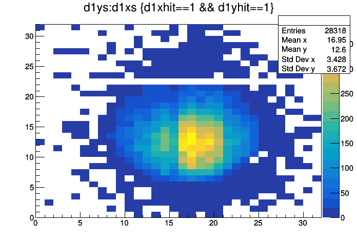

```python
tree->Draw("d1ys:d1xs>>(32,0,32,32,0,32)","d1xhit==1 && d1yhit==1","colz");
c1->Draw();
```

### 将满足所有满足条件的x-y关联事件存入ROOT文件

- 以x:12条和y:13条为例，将满足下列条件,以及在cut1范围内的所有关联事件存入TGraph *g1213

  ```
  bool bveto=d1x[11]<100 && d1x[13]<100 && d1y[12]<100 && d1y[14]<100;
  bool b1213=d1x[12]>200 && d1x[12]<8000 && d1y[13]>200&& d1y[13]<8000;
  bool bcut=bveto && b1213;
  ```

- 将所有x-y组合的TGraph 存入以gdet1.root为名的文件中

```python
//选择x-y方向条的范围，以每条计数大于1500为界限
int x1=13,x2=21;
int y1=8,y2=16;
cout<<"reference strip: ym = "<<ym<<endl;
```

```
reference strip: ym = 13
```

```python
TGraph *gr[32][32];
TFile *fg=new TFile("gdet1.root");
```

```python
for(int ix=0;ix<32;ix++) {
    for(int iy=0;iy<32;iy++) {
        gr[ix][iy]=new TGraph;
        gr[ix][iy]=(TGraph*)fg->Get(Form("g%02d%02d",ix,iy));
    }
}
```

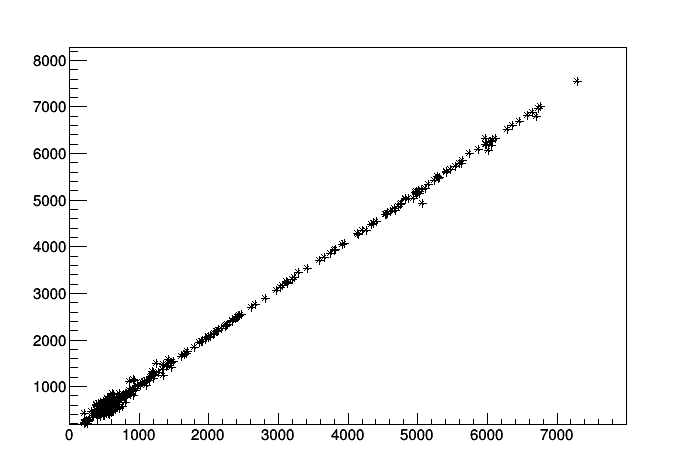

```python
gr[10][10]->Draw("A*");
c1->Draw();
```

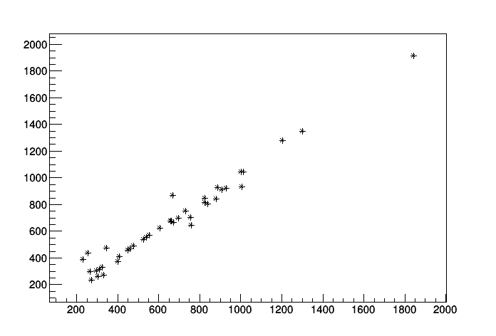

```python
gr[0][0]->Draw("A*");
c1->Draw();
```

## gFit

- IsXY = "X" for fitting g(x,y) with y=k*x+b
- IsXY = "Y" for fitting g(x,y) with x=k*x+b
- g: graph to be fitted
- hres: residual 2d-histogram
- par[3] for TF2
- stat[3]: ymin,ymax,Ncout for fitting
- minCount: minimum count for TGraph fitting

```python
bool gFit(char IsXY, TGraph *g, TH2F *hres, double* par, double &chi2ndf, int *sta,int minCount=20)
{
    //cout<<g->GetN()<<endl;
    if(g->GetN() < minCount)
        return 0;
    TGraph *g1=new TGraph;
    TGraph *g2=new TGraph;
    TF1 *fpa1= new TF1("fp1","pol1",200,8000);
    TF1 *fpa2= new TF1("fp2","pol2",200,8000);
    int ymin=10000, ymax=0;
    double par1[2];
    for(int k=0; k<g->GetN(); k++) {
            double x=g->GetX()[k];
            double y=g->GetY()[k];
            if(IsXY=='Y' or IsXY=='y') swap(x,y);//x=ky+b
            g1->SetPoint(k,x,y);
    }
    g1->Fit(fpa1,"Q ROB");
    fpa1->GetParameters(&par1[0]);
    int ng = 0;
    for(int k=0; k<g1->GetN(); k++) {
            double x=g1->GetX()[k];
            double y=g1->GetY()[k];
            if (abs(y-(par1[0]+par1[1]*x))<20) { //eliminate outliers
                g2->SetPoint(ng,x,y);
                ng++;
            }
    }
    if(g2->GetN()>= minCount) {
        g2->Fit(fpa2,"Q ROB");
        fpa2->GetParameters(&par[0]);
        chi2ndf=fpa2->GetChisquare()/fpa2->GetNDF();
        for(int j = 0;j < g2->GetN(); j++){
            double x=g2->GetX()[j];
            double y=g2->GetY()[j];
            hres->Fill(par[0]+par[1]*x+par[2]*x*x-y,y);
            if(y>ymax) ymax=y;
            if(y<ymin) ymin=y;
        }
    }
    sta[0]=ymin;
    sta[1]=ymax;
    sta[2]=g2->GetN();
    delete fpa1;
    delete fpa2;
    delete g1;
    delete g2;
    if(sta[2] < minCount)
        return 0;
    else
        return 1;
}
```

### Normalize xstrips to ys

- $Fit(A_{y_s}=k_{x_i}*A_{x_i}+b_{x_i};k_{x_i},b_{x_i} )$, $i=(x_1...x_2)$

```python
TH2F *hresx1=new TH2F("hresx1","hresx1",60,-30,30,1000,200,8000);
double parx[32][3],pary[32][3],chi2ndf;
int sta[3];
TString shead;
```

```python
shead.Form("%4s%9s%10s%15s%12s%5s%5s%8s","ix","p0","p1","p2","chi2/ndf","xmin","xmax","Nc");
cout<<shead<<endl;
for(int ix=x1;ix<=x2;ix++) {
    TString hname = Form("hresx1%02d",ix);
    bool sucess=gFit('X',gr[ix][ym],hresx1,parx[ix],chi2ndf,sta,20);
    if(!sucess) continue;
    TString pr;
    pr.Form("%4d%9.2f%10.6f%15e%12.2f%5d%5d%8d",
            ix,parx[ix][0],parx[ix][1],parx[ix][2],chi2ndf,sta[0],sta[1],sta[2]);
    cout<<pr<<endl;
}
```

```
  ix       p0        p1             p2    chi2/ndf xmin xmax      Nc
  13    -8.25  1.040484   3.390929e-07       28.84  209 7481     417
  14   -14.43  1.046044   6.007742e-07       29.78  201 7351     446
  15    -4.91  1.020304   5.992507e-07       27.07  202 7423     456
  16   -13.84  1.017886   4.668947e-07       19.98  206 7524     650
  17    -7.35  1.024276   4.578831e-07       21.52  201 7516     654
  18   -14.62  1.032498   4.647173e-07       21.78  204 7610     573
  19   -11.19  1.000312   3.717831e-07       28.22  206 7445     595
  20   -14.91  1.029676   4.853268e-07       22.66  227 7340     511
  21   -10.74  1.026826   6.761322e-07       25.36  204 7486     375
```

- 检查输出中xmin,xmax和Nc的值是否符合要求
  - xmin-xmax: 数据点中x的最小值-最大值，要覆盖需要刻度的幅度范围
  - Nc : 参与拟合点的数目，

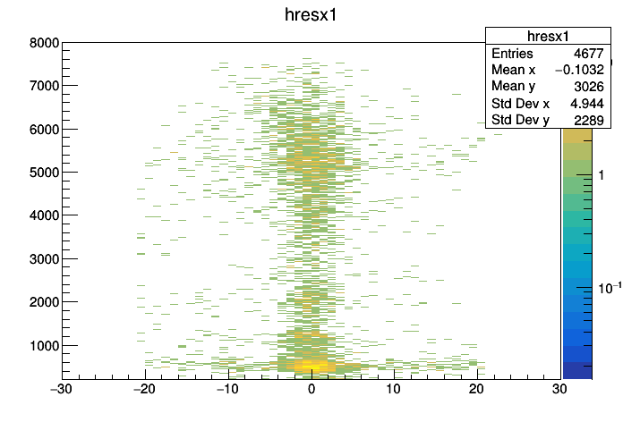

```python
hresx1->Draw("colz");
c1->SetLogz();
c1->Draw();
```

### CalibMerge

- Calibrate & Merge xstrips
- IsXY ='X' merge xstrips within the range of m1 to m2
  - ic: ystrip
  - gc: merged & calibrated graph for gr[m1-m2][ic]
- IsXY ='Y' merge ystrips within the range of m1 to m2
  - ic: xstrip
  - gc: merged & calibrated graph for gr[ic][m1-m2]

```python
void CalibMerge(char IsXY,int m1,int m2, int ic, TGraph *gc)
{
    gc->Clear();
    int ngy=0;
    if(IsXY=='X') {
        for(int ix=m1;ix<=m2;ix++) {
            for(int i=0;i<gr[ix][ic]->GetN();i++) {
                double x=gr[ix][ic]->GetX()[i];
                double y=gr[ix][ic]->GetY()[i];
                x = parx[ix][0]+parx[ix][1]*x+parx[ix][2]*x*x;
                gc->SetPoint(ngy,x,y);
                ngy++;
            }
        }
    }
    else {
        for(int iy=m1;iy<=m2;iy++) {
            for(int i=0;i<gr[ic][iy]->GetN();i++) {
                double x=gr[ic][iy]->GetX()[i];
                double y=gr[ic][iy]->GetY()[i];
                y = pary[iy][0]+pary[iy][1]*y+pary[iy][2]*y*y;
                gc->SetPoint(ngy,x,y);
                ngy++;
            }
        }
    }
}
```

### calibrate & merge xstrips

```python
TGraph *gryc[32];
for(int iy=0; iy<32; iy++) {
    gryc[iy] = new TGraph;
    CalibMerge('X',x1,x2,iy,gryc[iy]);
}
```

### Normalize ystrips

```python
TH2F *hresy1=new TH2F("hresy1","hresy1",60,-30,30,1000,200,8000);
shead.Form("%4s%9s%10s%15s%12s%5s%5s%8s","iy","p0","p1","p2","chi2/ndf","xmin","xmax","Nc");
cout<<shead<<endl;
for(int iy=0;iy<32;iy++) {
    bool sucess=gFit('Y',gryc[iy],hresy1,pary[iy],chi2ndf,sta,20);
    if(!sucess) continue;
    TString pr;
    pr.Form("%4d%9.2f%10.6f%15e%12.2f%5d%5d%8d",
            iy,pary[iy][0],pary[iy][1],pary[iy][2],chi2ndf,sta[0],sta[1],sta[2]);
    cout<<pr<<endl;
}
```

```
  iy       p0        p1             p2    chi2/ndf xmin xmax      Nc
   0     8.21  0.974475   1.471272e-07       32.35  200 6458     641
   1     0.47  0.995698  -1.424472e-07       26.96  202 6806    1003
   2     1.46  0.989480   2.451143e-07       22.62  201 7408    1430
   3     5.83  0.995079   1.747192e-08       20.71  202 7562    1815
   4    -6.87  0.996756   2.312951e-07       23.24  195 7587    2183
   5     0.61  1.006158  -1.873976e-08       22.26  202 7645    2445
   6    -5.28  1.002214  -1.381574e-08       21.69  196 7491    2937
   7     3.50  1.013427  -2.111302e-07       22.39  205 7709    3548
   8    -6.88  1.013042  -6.909218e-08       23.04  199 7705    4141
   9    -4.14  0.983625  -9.404912e-08       24.22  195 7541    4225
  10    -3.22  1.008195   2.372924e-09       23.39  199 7679    4459
  11    -0.46  1.002689  -1.371297e-07       23.91  201 7666    4619
  12    -1.97  1.020229   1.352245e-08       24.43  200 7778    4877
  13     0.01  0.999990   2.787740e-09       23.69  190 7609    4671
```

[output cut: 17 more lines]

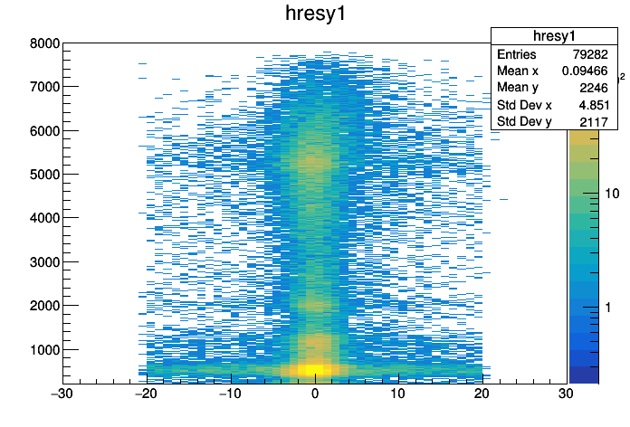

```python
hresy1->Draw("colz");
c1->Draw();
```

### Calibrate & Merge ystrips

```python
TGraph *grxc[32];
for(int ix=0; ix<32; ix++) {
    grxc[ix] = new TGraph;
    CalibMerge('Y',0,31,ix,grxc[ix]);
}
```

### Normalize xstrips

```python
TH2F *hresx2=new TH2F("hresx2","hresx2",60,-30,30,1000,200,8000);
cout<<"Final x parameters:"<<endl;
shead.Form("%4s%9s%10s%15s%12s%5s%5s%8s","ix","p0","p1","p2","chi2/ndf","xmin","xmax","Nc");
cout<<shead<<endl;
for(int ix=0;ix<32;ix++) {
    bool sucess=gFit('X',grxc[ix],hresx2,parx[ix],chi2ndf,sta,20);
    if(!sucess) continue;
    TString pr;
    pr.Form("%4d%9.2f%10.6f%15e%12.2f%5d%5d%8d",
            ix,parx[ix][0],parx[ix][1],parx[ix][2],chi2ndf,sta[0],sta[1],sta[2]);
    cout<<pr<<endl;
}
```

```
Final x parameters:
  ix       p0        p1             p2    chi2/ndf xmin xmax      Nc
   0    -4.22  1.019609   3.622314e-07       23.95  199 5779    1041
   1   -10.54  1.027801   2.291506e-07       22.94  197 6772    1606
   2   -14.52  1.027714   6.041123e-07       18.98  185 7334    2234
   3    -9.96  1.010694   4.446996e-07       19.69  190 5832    2885
   4   -14.80  1.019887   5.645767e-07       20.77  188 6400    3428
   5    -9.45  1.038584   3.739275e-07       20.20  195 7563    3781
   6   -14.26  1.033950   3.491857e-07       21.43  189 7381    4181
   7    -9.77  1.030867   2.621244e-07       21.23  196 7479    4541
   8   -14.06  1.027467   5.600976e-07       25.06  194 7366    4821
   9    -7.91  1.024422   6.306067e-07       23.11  186 7761    5303
  10   -12.08  1.041332   5.203650e-07       24.87  194 7606    5658
  11    -8.02  1.034851   5.906767e-07       27.19  195 7702    6021
  12   -12.04  1.013242   5.866603e-07       29.23  189 7691    6233
```

[output cut: 19 more lines]

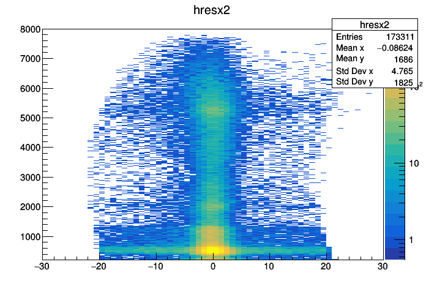

```python
hresx2->Draw("colz");
c1->Draw();
```

### Calibrate & Merge xstrips

```python
for(int iy=0; iy<32; iy++) {
    CalibMerge('X',0,31,iy,gryc[iy]);
}
```

### Normalize ystrips

- this step is to optimize fitting condition for ystrips
  - increase statistics
  - increase fitting range

```python
TH2F *hresy2=new TH2F("hresy2","hresy2",60,-30,30,1000,200,8000);
cout<<"Final y parameters:"<<endl;
shead.Form("%4s%9s%10s%15s%12s%5s%5s%8s","iy","p0","p1","p2","chi2/ndf","xmin","xmax","Nc");
cout<<shead<<endl;
for(int iy=0;iy<32;iy++) {
    bool sucess=gFit('Y',gryc[iy],hresy2,pary[iy],chi2ndf,sta,20);
    if(!sucess) continue;
    TString pr;
    pr.Form("%4d%9.2f%10.6f%15e%12.2f%5d%5d%8d",
            iy,pary[iy][0],pary[iy][1],pary[iy][2],chi2ndf,sta[0],sta[1],sta[2]);
    cout<<pr<<endl;
}
```

```
Final y parameters:
  iy       p0        p1             p2    chi2/ndf xmin xmax      Nc
   0     8.12  0.974471   1.700186e-07       26.73  200 6458    1803
   1     0.96  0.995246  -7.155419e-08       22.37  194 7086    2638
   2     1.45  0.989324   3.267861e-07       23.10  199 7408    3606
   3     5.66  0.995371  -5.676746e-08       21.09  196 7563    4546
   4    -6.53  0.996476   2.767462e-07       20.70  192 7588    5400
   5     0.63  1.005913   7.319036e-08       21.32  195 7641    5897
   6    -5.33  1.002242  -9.009470e-09       22.10  196 7575    6436
   7     3.59  1.013301  -1.926651e-07       22.18  200 7709    7287
   8    -6.78  1.012873  -3.180198e-08       22.45  189 7705    8138
   9    -4.09  0.983565  -8.191354e-08       23.33  193 7541    8364
  10    -3.31  1.008223   8.907521e-09       23.23  196 7680    8690
  11    -0.39  1.002466  -9.413551e-08       24.20  189 7666    8970
  12    -1.89  1.020066   4.876128e-08       24.02  197 7778    9341
```

[output cut: 18 more lines]

- y:13为参考条，拟合系数p0,p2应该接近于零，p1应接近1

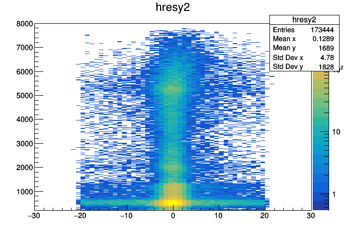

```python
hresy2->Draw("colz");
c1->Draw();
```

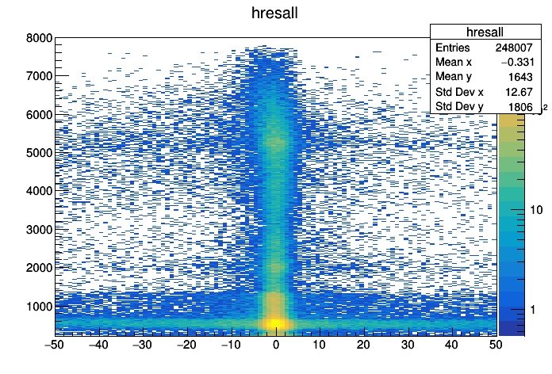

```python
TH2F *hresall = new TH2F("hresall","hresall",100,-50,50,1000,200,8000);
TH2F *hxy = new TH2F("hxy","hxy",1000,200,8000,1000,200,8000);
TH2F *hxycal = new TH2F("hxycal","hxycal",1000,200,8000,1000,200,8000);
hresall->Reset();
for(int ix=0;ix<32; ix++) {
   for(int iy=0;iy<32;iy++) {
    for(int i=0;i<gr[ix][iy]->GetN();i++) {
        double x=gr[ix][iy]->GetX()[i];
        double y=gr[ix][iy]->GetY()[i];
        hxy->Fill(x,y);
        x = parx[ix][0]+parx[ix][1]*x+parx[ix][2]*x*x;
        y = pary[iy][0]+pary[iy][1]*y+pary[iy][2]*y*y;
        hxycal->Fill(x,y);
        hresall->Fill(x-y,y);
    }
   }
}
hresall->Draw("colz");
c1->Draw();
```

- 从残差分布看高能段有些偏。主要的原因是1000以下信号过多，拟合时低能段权重过大。
  - 解决方法，减少参与拟合的低能段事件数目
  - 可先将TGraph转换成TH2，再将TH2转成TGraph(TH2上每个格子上的点，在TGpaph中表达成一个点)，此时每个区域的权重完全相等。

### 刻度结果

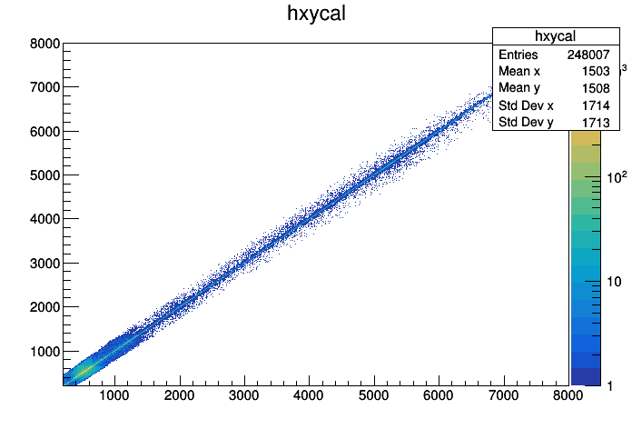

```python
c1->Clear();
hxycal->Draw("colz");
c1->Draw();
```

```python
TFile *fcal=new TFile("cal_16C.root");
TTree *tr=(TTree*)fcal->Get("tree");
```

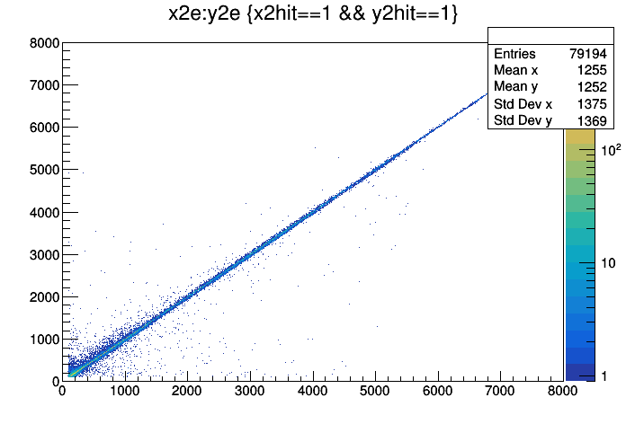

```python
tr->Draw("x2e:y2e>>(1000,0,8000,1000,0,8000)","x2hit==1 && y2hit==1","colz");
c1->Draw();
```

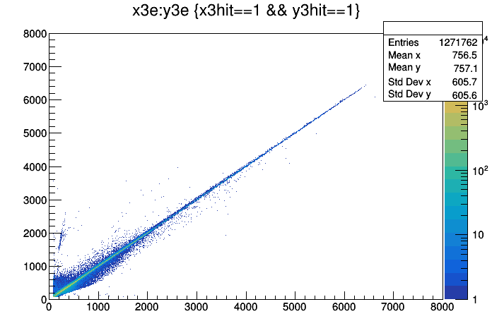

```python
tr->Draw("x3e:y3e>>(1000,0,8000,1000,0,8000)","x3hit==1 && y3hit==1","colz");
c1->Draw();
```